# Predicting Fatal Car Accidents in Brazil

Amber Han

Winter 2026

[figure not shown]

*Fig 1. Brazilian Highway*

```r
library(tidyverse)
library(tidymodels)
library(ggplot2)
library(corrplot)
library(ggthemes)
library(rsample)
library(recipes)
library(yardstick)
tidymodels_prefer()
library(readr)
library(dplyr)
library(naniar)
library(forcats)
library(recipes)
library(workflows)
library(parsnip)
library(gbm)
library(discrim)
library(bookdown)
set.seed(18294)
```

# Introduction

According to the National Library of Medicine[^1], Brazil ranks 5th in the number of deaths due to road injuries at approximately 40,000 deaths per year. Where there are survivors, these accidents irreversibly alter a person in some shape or form, even if they are just witnesses. By comparison, the number of deaths from motor vehicle crashes in the Unites States in 2023 was 40,901 deaths, according to the Insurance Institute for Highway Safety (IIHS)[^2]. Though these numbers are similar, Brazil has a population of 213.5 million people whereas the United States has a population of 342.5 million people. With a noticeably smaller population size, the similar deaths per year is concerning for Brazilians. The aim of this project is to build a machine learning model that will predict how fatal a car accident is in Brazil.

[figure not shown]

*Fig 2. Rio (2011)*

Brazil has always been an interest of mine, I want to visit and learn Brazilian Portuguese. A couple of my favorite fictional characters have ties to Brazil, including and not limited to the hit musical comedy animated film *Rio*. As a passing fan, I find it only fair to try to make something useful for a place I admire instead of simply consuming what the culture has to offer. This machine learning model was made with the idea of improving public safety, if people were more aware of the patterns that create a fatal car accident they may be able to approach driving with more caution. It may also be able to aid with informing policies and legislation that are related to road safety.

To clearly begin this project, it is necessary to define some of the elements I will encounter during the building of the model. The situation I am trying to predict is a classification problem, where I am predicting a category the outcome belongs to, such as my outcome variable and whether it belongs to the categories of whether an accident is a fatal accident or not. A machine learning model takes a data set and finds patterns that are useful in making educated decisions on data that has never been seen before. The goal is to find these patterns and use them to predict new cases and determine if the accident was a fatal one or not.

This data set was obtained through the data set hub Kaggle, labeled “Car Accidents in Brazil (2017-2023)”[^3] This is a register of traffic accidents that is open to anyone on the official Brazilian government website.

## Exploring my Data

### Loading my data

```r
# Reading in the original file
accidents <- read_csv("accidents_english.csv")
```

463152 rows and 27 columns. This immediately intimidates me and I am wondering if I actually need all of these observations in order to predict the severity of a car accident in Brazil.

### Checking if NA values exist in my data

No data set is impervious to errors, even if the data set originates from a governmental body. There may be some missing data which I am interested in removing for their lack of use.

```r
colSums(is.na(accidents))
```

```
##       inverse_data           week_day               hour              state
##                  0                  0                  0                  0
##            road_id                 km               city  cause_of_accident
##                990                990                  0                  0
##   type_of_accident  victims_condition  weather_timestamp     road_direction
##                  0                  0                  0                  0
## wheather_condition          road_type   road_delineation             people
##                  0                  0                  0                  0
##             deaths   slightly_injured   severely_injured          uninjured
##                  0                  0                  0                  0
##            ignored      total_injured  vehicles_involved           latitude
##                  0                  0                  0                  0
##          longitude           regional     police_station
##                  0                  1                  1
```

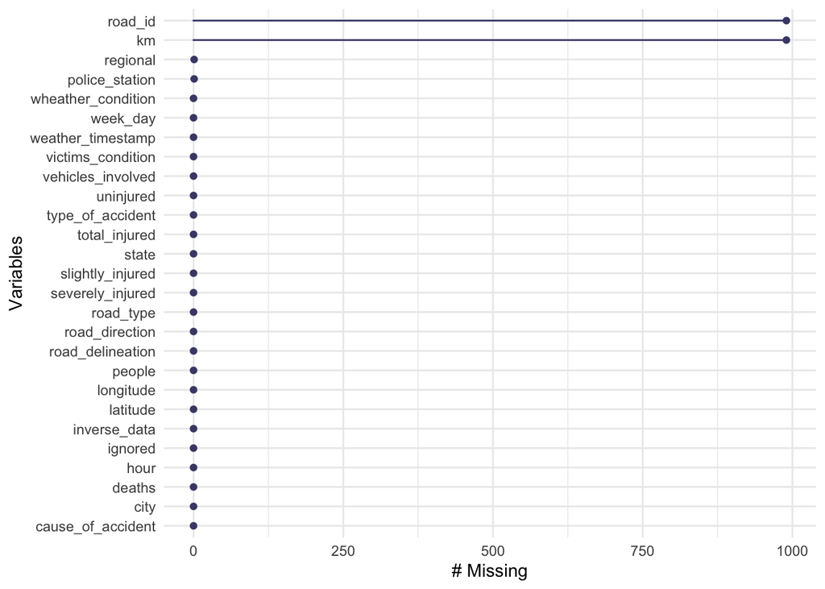

```r
accidents %>%
  gg_miss_var()
```

There are 990 missing values in both `road_id` and `km`. There is one missing value in both `regional` and `police_station`. All other columns have zero missing values. I am going to omit these two variables, as `road_id` and `km` are irrelevant to my prediction. `regional`, `police_station`, `week_day`, `hour`, `victims_condition`, `city`, `road_type`, `people`, `ignored`, `slightly_injured`, `uninjured`, `total_injured`, `road_direction`, `latitude`, and `longitude` are not completely necessary for the prediction of fatal accidents.

`regional` is a column that contains characters that do not have a discernible specification when I try to look up the region. With this lack of clarity, I am excluding it. `police_station` is a similar column that I cannot make sense of. `city` is omitted due to how many officially recognized cities there are — there are 5,570 cities in Brazil and I worry its size will create a large number of dummy variables that will be too many for my models to handle. I also find that the variable is on the redundant side as I keep the `state` variable. `week_day` and `hour` are hyper-specific and does not offer more patterns for predicting the fatality of an accident than the existing `inverse_data` column. `slightly_injured`, `uninjured`, `victims_condition`, and `total_injured` are not included based on the definition of fatality I have outlined below. Since they are not integral to determining which observations are fatal, they are not necessitated to be run through my models and give it unnecessary information. `road_type` and `road_direction` is redundant to `road_delineation` and is thus omitted, only one of them will suffice. `latitude` and `longitude` also appeared to be hyper-specific, and it would be difficult to track any pattern if every observation has their unique coordinate and thus be inconsequential to the model.

Because I find that these variables are unnecessary and may actualy hinder my modelling, I will remove them.

```r
# dropping aforementioned irrelevant predictors
newaccidents <- subset(accidents, select = -c(road_id, km, regional, police_station, week_day, victims_condition, city, road_type, people, slightly_injured, uninjured, ignored, total_injured, latitude, longitude, road_direction, hour))

head(newaccidents)
```

```
## # A tibble: 6 × 10
##   inverse_data state cause_of_accident        type_of_accident weather_timestamp
##   <date>       <chr> <chr>                    <chr>            <chr>
## 1 2017-01-01   RS    Mechanical loss/defect … Rear-end collis… Night
## 2 2017-01-01   PR    Incompatible velocity    Run-off-road     Night
## 3 2017-01-01   BA    Driver was sleeping      Head-on collisi… Sunrise
## 4 2017-01-01   PA    Driver's lack of attent… Side impact col… Sunrise
## 5 2017-01-01   GO    Road's defect            Collision with … Day
## 6 2017-01-01   RN    Alcohol consumption      Head-on collisi… Day
## # ℹ 5 more variables: wheather_condition <chr>, road_delineation <chr>,
## #   deaths <dbl>, severely_injured <dbl>, vehicles_involved <dbl>
```

### Checking if there are duplicates

```r
sum(duplicated(accidents))
```

```
## [1] 9
```

Additionally, if there are any duplicates, redundancy confuses the model and thus it is necessary to remove them.

```r
accidents[duplicated(accidents), ]
```

```
## # A tibble: 9 × 27
##   inverse_data week_day  hour   state road_id km    city       cause_of_accident
##   <date>       <chr>     <time> <chr>   <dbl> <chr> <chr>      <chr>
## 1 2017-10-20   friday    14:25  SC        282 483,9 FAXINAL D… Disrespect of sa…
## 2 2017-11-11   saturday  17:00  GO         60 201,8 GUAPO      Slippery track
## 3 2017-11-19   sunday    15:40  RJ         40 113   DUQUE DE … Road's defect
## 4 2021-12-16   thursday  17:30  SC        101 135,3 BALNEARIO… Acessing the roa…
## 5 2022-03-30   wednesday 20:19  GO         50 263,5 CATALAO    Driver's lack of…
## 6 2022-05-25   wednesday 15:32  AM        174 888   MANAUS     Driver's lack of…
## 7 2022-05-15   sunday    17:00  AM        174 914   MANAUS     Driver's lack of…
## 8 2022-09-29   thursday  22:15  RJ        356 167   SAO JOAO … Driver using cel…
## 9 2022-10-24   monday    19:50  RS        116 250   SAO LEOPO… Static object on…
## # ℹ 19 more variables: type_of_accident <chr>, victims_condition <chr>,
## #   weather_timestamp <chr>, road_direction <chr>, wheather_condition <chr>,
## #   road_type <chr>, road_delineation <chr>, people <dbl>, deaths <dbl>,
## #   slightly_injured <dbl>, severely_injured <dbl>, uninjured <dbl>,
## #   ignored <dbl>, total_injured <dbl>, vehicles_involved <dbl>,
## #   latitude <dbl>, longitude <dbl>, regional <chr>, police_station <chr>
```

```r
accidents <- unique(accidents)
```

I’ve also detected 9 duplicates in my data. I will also take it upon myself to remove these observations even though the small amount may not be significant to my results.

## What counts as a “fatal” accident?

To continue with this project I need an outcome variable, which I currently do not possess. The aim of the project is to predict which car accidents are fatal or not in the country of Brazil, so I am interested in fatality and thus will create a new outcome variable based on my existing data set which I will measure, use, and analyze.

But what even qualifies as a “fatal” accident? How am I supposed to create this variable and what am I supposed to base it off of?

Well, the National Highway Traffic Safety Administration (NHTSA)[^4] classifies a fatal crash as “A Police-reported Crash Involving A Motor Vehicle In Transport On A Trafficway In Which At Least One Person Dies Within 30 Days Of The Crash,” so I will be looking at the “deaths” column of my data. Although the definition only includes death in its definition for a car accident to be considered fatal, non-fatal injuries often leave victims disabled and at a higher risk of death afterwards. So to determine whether an accident is fatal in this model, I will be using the variables “deaths” and “severely_injured.” An accident will be considered fatal if any death occurred and/or if a severe injury occurred.

Here is how I create this variable:

### Creating a new outcome variable

```r
# Creating new column "fatal" that is determined if the accident has deaths > 0 OR severely_injured > 0
newaccidents <- newaccidents %>%
  mutate(fatal = ifelse(deaths > 0 | severely_injured > 0, "Yes", "No")) %>%
  mutate(fatal = factor(fatal))

names(newaccidents)
```

```
##  [1] "inverse_data"       "state"              "cause_of_accident"
##  [4] "type_of_accident"   "weather_timestamp"  "wheather_condition"
##  [7] "road_delineation"   "deaths"             "severely_injured"
## [10] "vehicles_involved"  "fatal"
```

Success! The a new variable `fatal` has been created and will serve as my outcome variable. It is a column filled with either “Yes” or “No” depending on if the accident contained any number greater than 0 in the deaths or severe injuries columns.

### Codebook

Now that we have all of our variables, here is a brief codebook on all the existing variables in the dataset.

- `inverse_data`: Data when the accidents occurred (yyyy-mm-dd) (date).
- `state`: State acronyms (like New York (NY))
- `cause_of_accident`: What created the accident in the first place.
- `type_of_accident`: What happened to the vehicle(s)
- `weather_timestamp`: Stage of day (Sunrise, Day, Sundown, Night)
- `weather_condition`: What type of weather is occurring (i.e. Clear sky, Drizzle, Cloudy, etc.)
- `road delineation`: What kind of road that is being traveled across (i.e. Straight, curve, clear sky, and more)
- `deaths`: death count of the accident
- `severely_injured`: Count of how many people were severely injured
- `uninjured`: Count of how many people were uninjured during the accident
- `week_day`: Days of week(s,m,t,w,t,s,f,s) (ordinal)
- `fatal`: Whether the accident was fatal or not.

### More Tidying Data

Currently, the dates are displayed in the “YYYY-MM-DD” format in the “inverse_data” column. I want to extract the dates into two columns that just display the month and year. The specific days are less significant in capturing trends, whereas month and year can more succinctly identify any seasonality that may appear within the accidents.

```r
# Extracting the months and year
dates <- newaccidents$inverse_data

# adding the extracted months and year into their own columns
newaccidents$year <- format(as.Date(dates), "%Y")
newaccidents$month <- format(as.Date(dates), "%m")
```

```r
# checking if the columns were successfully created
names(newaccidents)
```

```
##  [1] "inverse_data"       "state"              "cause_of_accident"
##  [4] "type_of_accident"   "weather_timestamp"  "wheather_condition"
##  [7] "road_delineation"   "deaths"             "severely_injured"
## [10] "vehicles_involved"  "fatal"              "year"
## [13] "month"
```

Success again. `year` and `month` are newly created columns that I will be able to work with and use as predictors.

```r
# Dropping the inverse_data column to just have "year" and "month"
newaccidents <- subset(newaccidents, select = -c(inverse_data))

# Relocating the dates column to the front
newaccidents1 <- relocate(newaccidents, month, .before = cause_of_accident)
newaccidents2 <- relocate(newaccidents1, year, .before = month)

# Making Year and Month numeric as they are currently character variables
newaccidents2$year <- as.numeric(newaccidents2$year)
newaccidents2$month <- as.numeric(newaccidents2$month)

names(newaccidents2)
```

```
##  [1] "state"              "year"               "month"
##  [4] "cause_of_accident"  "type_of_accident"   "weather_timestamp"
##  [7] "wheather_condition" "road_delineation"   "deaths"
## [10] "severely_injured"   "vehicles_involved"  "fatal"
```

```r
# Renaming the column "wheather_condition" to "weather_condition"
newaccidents2 <- newaccidents2 %>%
  rename(
    weather_condition = wheather_condition
  )

names(newaccidents2)
```

```
##  [1] "state"             "year"              "month"
##  [4] "cause_of_accident" "type_of_accident"  "weather_timestamp"
##  [7] "weather_condition" "road_delineation"  "deaths"
## [10] "severely_injured"  "vehicles_involved" "fatal"
```

```r
# Counting the amount of unique values of the aforementioned variables

tibble(
  variable = c("state", "cause_of_accident", "type_of_accident", "weather_timestamp", "weather_condition", "road_delineation", "vehicles_involved"),
  unique_values = c(
    length(unique(newaccidents2$state)),
    length(unique(newaccidents2$cause_of_accident)),
    length(unique(newaccidents2$type_of_accident)),
    length(unique(newaccidents2$weather_timestamp)),
    length(unique(newaccidents2$weather_condition)),
    length(unique(newaccidents2$road_delineation)),
    length(unique(newaccidents2$vehicles_involved))
  )
)
```

```
## # A tibble: 7 × 2
##   variable          unique_values
##   <chr>                     <int>
## 1 state                        27
## 2 cause_of_accident            85
## 3 type_of_accident             21
## 4 weather_timestamp             4
## 5 weather_condition            10
## 6 road_delineation             10
## 7 vehicles_involved            18
```

```r
# Turning the non-numeric variables into factors

newaccidents2$state <- factor(newaccidents2$state, labels = c("RS", "PR",  "BA", "PA", "GO", "RN", "MG", "MT", "MA", "SP", "TO", "PE", "ES", "AL", "SC", "PB", "RO", "CE", "SE", "RJ", "MS", "PI", "AM", "DF", "RR", "AC", "AP"))

newaccidents2$weather_timestamp <- factor(newaccidents2$weather_timestamp, labels = c("Sunrise", "Day", "Sunset", "Night")) # labels ordered from earliest to latest

newaccidents2$weather_condition <- factor(newaccidents2$weather_condition, labels = c("Clear sky", "Drizzle", "Cloudy", "Sunny", "Rainy", "Fog", "Ignored", "Windy", "Hail", "Snowy"))

newaccidents2$road_delineation <- factor(newaccidents2$road_delineation, labels = c("Straight", "Curve", "Temporary Detour", "Not Reported", "Intersection", "Authorized U-turn", "Overpass", "Roundabout", "Bridge", "Tunnel"))

newaccidents2$type_of_accident <- factor(newaccidents2$type_of_accident, labels = c("Rear-end collision", "Run-off-road", "Head-on collision", "Side impact collision", "Collision with fixed object", "Overturn", "Collision with moving object", "Cargo spill", "Pedestrian collision", "Broadside collision", "Vehicle fire", "Rollover", "Animal collision", "Chain reaction crash (pile-up)", "Minor incidental damage", "Fall of vehicle occupant", "Collision with object", "Not informed", "Side collision (same direction)", "Unusual events", "Side collision (opposite direction)"))

newaccidents2$cause_of_accident <- factor(newaccidents2$cause_of_accident, labels = c("Mechanical loss/defect of vehicle", "Incompatible velocity", "Driver was sleeping", "Driver's lack of attention to conveyance", "Road's defect", "Alcohol consumption", "Disrespect of safe distance from the next car", "Slippery track", "Pedestrian's lack of attention", "Driver broke the laws of transit", "Natural phenomena", "Animals on the road", "The driver passed the next car improperly", "Cardiac attack", "Excessive load/cargo", "Static object on the drainage gate", "Excessive use of the car's tire", "Inadequate sinalization of the road", "Deficiency of vehicle's sinalization/ilumination system", "Visibility restriction", "Drug ingestion", "Driver's lack of reaction", "External fight", "Disobedience to laws of transit by the pedestrian", "Alcohol and/or drug ingestion by the pedestrian", "Road had lots of sand/wreckage", "Alcohol ingestion by the driver", "Curvy road", "Disrespecting the intersection", "Pedestrian was walking in the road", "Electrical or mechanical flaws", "Driver was in the opposite direction", "Unlevel track", "Rain", "Roads with holes without cement", "Road works (in maintenance)", "Lane change maneuver", "Oil accumulation on the road", "Driver disrespected the red traffic light", "Driver using cellphone", "Uneven breakdown lane", "Prohibited conversion", "Acessing the road without seeing the presence of other vehicles", "No breakdown lanes", "Driver had a cardiac attack", "Accumulation of water on the road", "Driver failed to keep distance from the vehicle in front", "Unexpected pedestrian entry", "Absence of sinalization", "Driving on the breakdown lane", "Traffic with a motorcycle (or similar) between lanes", "Other flaws/problems in the road", "Pedestrian was crossing the road outside of the crosswalk", "Abrupt use of the car's brake", "Sinking or ondulation in the pavement", "Smoke", "Stopping at a prohibited place", "Poor ilumination (of the road)", "Irregular access", "Car's brake problem", "Driver changed the lane illegally", "Obstacle in the road", "Driver was using drugs", "Temporary return", "Urban area without appropriate pedestrian walking", "Bad positioning of traffic sign posts", "Traffic lights with problems", "Prominent downhill", "Pedestrian crosswalk with insufficient width", "Visibility restrictions in vertical curves", "Fog", "Visibility restrictions in horizontal curves", "Car's suspension system with problems", "engaging in drifting", "prohibited modification (of the car)", "car's on sidewalk", "unregulated headlights", "inefficiency of the drenage system", "speed reducer wasn't working correctly", "Failed to activate the motorcycle headlight (or similar)", "hidden/covered sinalization (of the road)", "robbery attempt", "driving on the breakdown lane", "suicide (presumed)", "mental disorder (except suicide)"))
```

```r
newaccidents2 <- newaccidents2[newaccidents2$year != 2017, ]
newaccidents2 <- newaccidents2[newaccidents2$year != 2018, ]
newaccidents2 <- newaccidents2[newaccidents2$year != 2019, ]
table(newaccidents2$year)
```

```
##
##  2020  2021  2022  2023
## 63576 64539 64547 44035
```

```r
count(newaccidents2)
```

```
## # A tibble: 1 × 1
##        n
##    <int>
## 1 236697
```

For ease of running my future models, I’ve excluded the years of 2017, 2018, and 2019 therefore eliminating 226,455 observations. For the rest of this project, I will be working with the remaining 236,697 observations.

The finalized list of predictors that will be relevant for my model are as follows:

- state
- cause_of_accident
- type_of_accident
- weather_timestamp
- weather_condition
- road_delineation
- vehicles_involved
- month
- year

## Visual EDA

I have defined a good number of predictors that may have a hand in causing a fatal accident. First off, let’s take a look at the ratio of fatal accidents to non-fatal accidents now that I have added the definition of what a fatal accident is.

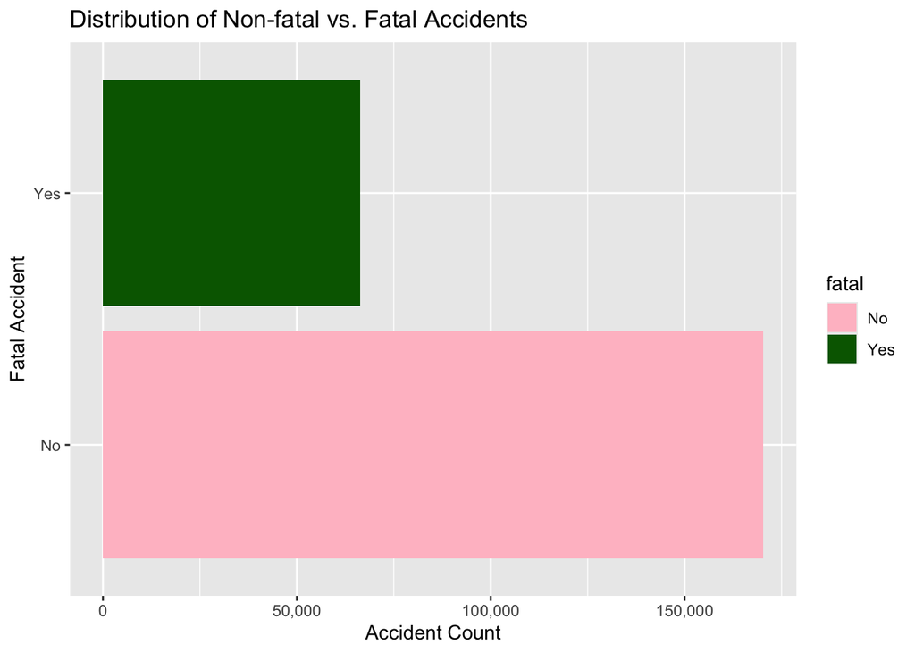

```r
ggplot(newaccidents2, aes(x = fatal, fill = fatal)) +
  geom_bar() +
  scale_y_continuous(labels = comma) +
  scale_fill_manual(values = c("No" = "pink", "Yes" = "darkgreen")) +
  coord_flip() +
  labs(title = "Distribution of Non-fatal vs. Fatal Accidents",
       x = "Fatal Accident",
       y = "Accident Count")
```

There is an overwhelming amount of non-fatal accidents compared to fatal accidents. To me, I am noting a class imbalance and the potential variability in the performance of the later models that this may cause. This does not, however, diminish the significance of having over 50,000 fatal accidents.

Now let me get into my predictors and have a preview on which ones may be most important or not.

### State

```r
newaccidents2 %>%
  group_by(state) %>%
  summarize(fatal_rate = mean(fatal == "Yes"))
```

```
## # A tibble: 27 × 2
##    state fatal_rate
##    <fct>      <dbl>
##  1 RS         0.327
##  2 PR         0.381
##  3 BA         0.314
##  4 PA         0.327
##  5 GO         0.336
##  6 RN         0.350
##  7 MG         0.188
##  8 MT         0.344
##  9 MA         0.281
## 10 SP         0.432
## # ℹ 17 more rows
```

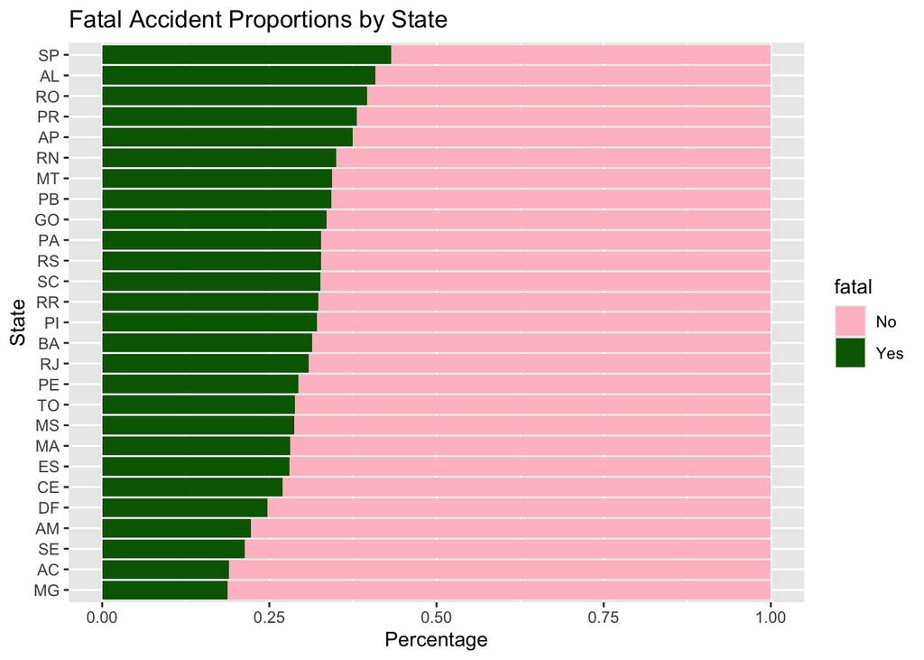

```r
state_asc <- newaccidents2 %>%
  group_by(state) %>%
  summarize(fatal_rate = mean(fatal == "Yes")) %>%
  arrange(fatal_rate) %>%
  pull(state)

newaccidents2$state <- factor(newaccidents2$state, levels = state_asc)

ggplot(newaccidents2, aes(x = state, fill = fatal)) +
  geom_bar(position = "fill") +
  scale_fill_manual(values = c("No" = "pink", "Yes" = "darkgreen")) +
  coord_flip() +
  labs(
    title = "Fatal Accident Proportions by State",
    x = "State",
    y = "Percentage"
  )
```

Location, like a state, is a fair variable to have as a predictor because of the variability in environments that can contribute to fatal accidents. I am not aware of the economic makeup of Brazil across its states, but in general everywhere, wealthier areas will have better infrastructure and road construction, typically meaning safer roads that will have more frequent maintenance.

It seems that “SP,” or Sao Paulo, has the highest fatality rate over all the states. Sao Paulo does contradict my previous statement a little, as it is one of the most financially flourishing states in Brazil, but it is also the most populated state in Brazil, and where there is more traffic there are more accidents. A fatality rate of 43.22% is relatively high in comparison to United States fatality rates.

### Weather Conditions

According to the U.S. Department of Transportation’s Federal Highway Administration[^5] (FHWA), “On average, there are over 6,035,000 million vehicle crashes each year. Approximately 12 percent of these crashes - nearly 745,000 - are weather-related. Weather-related crashes are defined as those crashes that occur in adverse atmospheric weather conditions (e.g., rain, sleet, hail, snow, freezing rain or drizzle, fog, smog, smoke, severe crosswinds, or blowing snow, sand, soil or dust).” Although these are claims from the United States, causes for car accidents typically remain universal and warrants the weather being looked into for how it contributes to fatal car accidents in Brazil. The figures below examine the percentage and proportions of weather conditions and how they contribute to fatal car accidents compared to one another.

```r
newaccidents2 %>%
  group_by(weather_condition) %>%
  summarize(fatal_rate = mean(fatal == "Yes")) %>%
  arrange(desc(fatal_rate))
```

```
## # A tibble: 10 × 2
##    weather_condition fatal_rate
##    <fct>                  <dbl>
##  1 Fog                   0.363
##  2 Snowy                 0.331
##  3 Sunny                 0.315
##  4 Clear sky             0.291
##  5 Drizzle               0.275
##  6 Hail                  0.264
##  7 Ignored               0.242
##  8 Cloudy                0.224
##  9 Windy                 0.167
## 10 Rainy                 0.0909
```

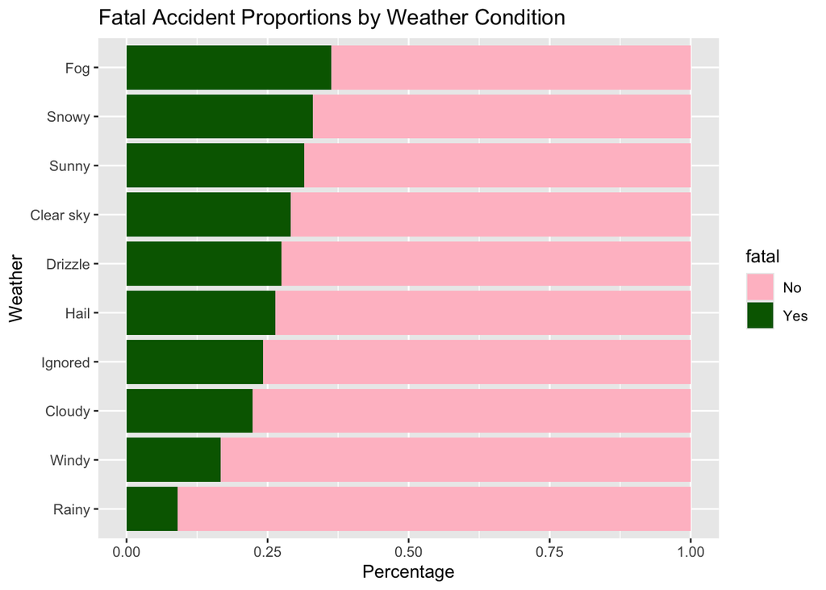

```r
weather_asc <- newaccidents2 %>%
  group_by(weather_condition) %>%
  summarize(fatal_rate = mean(fatal == "Yes")) %>%
  arrange(fatal_rate) %>%
  pull(weather_condition)

ggplot(newaccidents2, aes(x = factor(weather_condition, levels = weather_asc), fill = fatal)) +
  geom_bar(position = "fill") +
  scale_fill_manual(values = c("No" = "pink", "Yes" = "darkgreen")) +
  coord_flip() +
  labs(
    title = "Fatal Accident Proportions by Weather Condition",
    x = "Weather",
    y = "Percentage"
  )
```

### Weather Timestamp

```r
newaccidents2 %>%
  group_by(weather_timestamp) %>%
  summarize(fatal_rate = mean(fatal == "Yes")) %>%
  arrange(desc(fatal_rate))
```

```
## # A tibble: 4 × 2
##   weather_timestamp fatal_rate
##   <fct>                  <dbl>
## 1 Day                    0.323
## 2 Night                  0.300
## 3 Sunset                 0.296
## 4 Sunrise                0.249
```

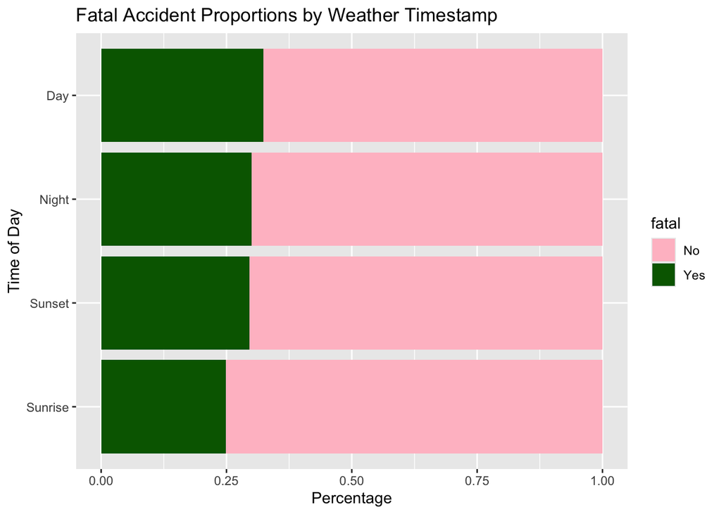

```r
daytime_asc <- newaccidents2 %>%
  group_by(weather_timestamp) %>%
  summarize(fatal_rate = mean(fatal == "Yes")) %>%
  arrange(fatal_rate) %>%
  pull(weather_timestamp)

ggplot(newaccidents2, aes(x = factor(weather_timestamp, levels = daytime_asc), fill = fatal)) +
  geom_bar(position = "fill") +
  scale_fill_manual(values = c("No" = "pink", "Yes" = "darkgreen")) +
  coord_flip() +
  labs(
    title = "Fatal Accident Proportions by Weather Timestamp",
    x = "Time of Day",
    y = "Percentage"
  )
```

Across different times of day, there is actually not much difference in the proportion of fatal accidents that occur. Daytime is not overwhelmingly more likely to have a fatal accident than night time is. Due to this, I anticipate a weak predictive power from weather_timestamp in the model.

The fatality of an accident can also vary by what kind of accident occurred. A cargo spill that obstructs the road does not necessarily equate the same danger that a head-on collision may incur.

### Type of Accident

```r
newaccidents2 %>%
  group_by(type_of_accident) %>%
  summarize(fatal_rate = mean(fatal == "Yes")) %>%
  arrange(desc(fatal_rate))
```

```
## # A tibble: 20 × 2
##    type_of_accident                    fatal_rate
##    <fct>                                    <dbl>
##  1 Animal collision                       0.679
##  2 Pedestrian collision                   0.621
##  3 Collision with object                  0.343
##  4 Run-off-road                           0.333
##  5 Rear-end collision                     0.288
##  6 Overturn                               0.271
##  7 Cargo spill                            0.248
##  8 Unusual events                         0.239
##  9 Chain reaction crash (pile-up)         0.228
## 10 Rollover                               0.224
## 11 Fall of vehicle occupant               0.220
## 12 Side collision (same direction)        0.217
## 13 Collision with fixed object            0.213
## 14 Collision with moving object           0.206
## 15 Not informed                           0.202
## 16 Minor incidental damage                0.201
## 17 Broadside collision                    0.121
## 18 Side impact collision                  0.119
## 19 Head-on collision                      0.0885
## 20 Side collision (opposite direction)    0.00439
```

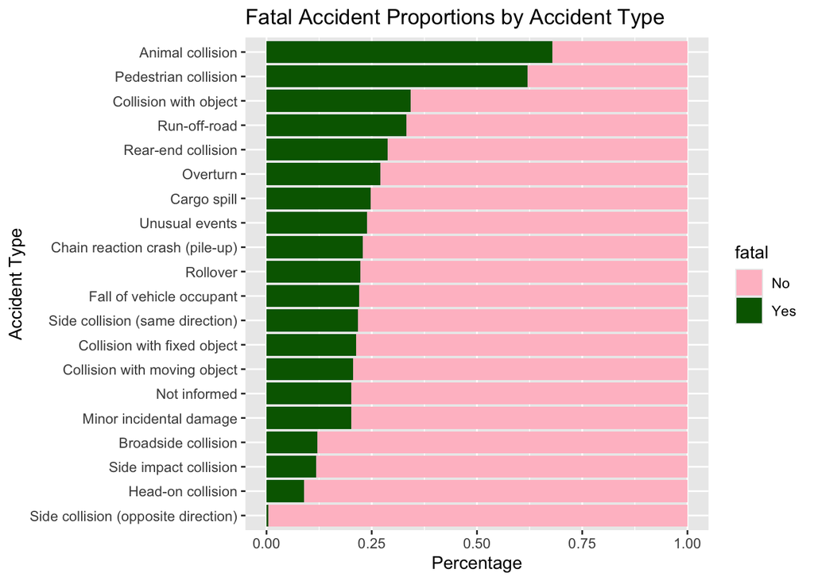

```r
acctype_asc <- newaccidents2 %>%
  group_by(type_of_accident) %>%
  summarize(fatal_rate = mean(fatal == "Yes")) %>%
  arrange(fatal_rate) %>%
  pull(type_of_accident)

ggplot(newaccidents2, aes(x = factor(type_of_accident, levels = acctype_asc), fill = fatal)) +
  geom_bar(position = "fill") +
  scale_fill_manual(values = c("No" = "pink", "Yes" = "darkgreen")) +
  coord_flip() +
  labs(
    title = "Fatal Accident Proportions by Accident Type",
    x = "Accident Type",
    y = "Percentage"
  )
```

It appears that animal collisions and pedestrian collisions more often become fatal accidents than non-fatal accidents, with both reaching over 50% in fatal accidents, animal collisions being 67.94% fatal and pedestrian collisions being 62.06% fatal. All other accident types have less than 35% of accidents that are fatal. The least likely types of accident are side impact collisions at 11.85%, head-on collisions at 8.85%, and side-collisions (opposite direction) at 0.44%. This was baffling to me at first to consider animal collisions being more fatal than head-on collisions, but possibly due to my definition of fatal to include severe injuries, accident types like animal collisions that have overwhelming severe injuries yet don’t kill anyone shoot to the top of the fatality list. `type_of_accident` may be a strong predictor for my model with the amount of variety and distribution there is among itself.

### Cause of Accident

[figure not shown]

```r
ggplot(newaccidents2, aes(x = cause_of_accident, fill = fatal)) +
  geom_bar(position = "fill") +
  theme(axis.text.x = element_text(angle = 90)) +
  scale_fill_manual(values = c("No" = "pink", "Yes" = "darkgreen")) +
  coord_flip() +
  labs(
    title = "Fatal Accident Proportion by Cause of Accident",
    x = "Cause of Accident",
    y = "Percentage"
  )
```

Well this is unreadable! Let me pivot and change to a different form of visualization.

As we have found before, there are 85 different and unique causes of accidents, so I am going to attempt to only use the top 10-15 most frequent causes.

```r
top_causes <- newaccidents2 %>% # taking the top 15
  count(cause_of_accident, sort = TRUE) %>%
  slice_head(n = 15) %>%
  pull(cause_of_accident)

newaccidents2 %>% # the percentages
  filter(cause_of_accident %in% top_causes) %>%
  group_by(cause_of_accident) %>%
  summarize(
    total = n(),
    fatal_count = sum(fatal == "Yes"),
    fatal_rate = round(fatal_count / total * 100, 1)
  ) %>%
  arrange(desc(fatal_count/total))
```

```
## # A tibble: 15 × 4
##    cause_of_accident                                total fatal_count fatal_rate
##    <fct>                                            <int>       <int>      <dbl>
##  1 Alcohol and/or drug ingestion by the pedestrian   5416        3257       60.1
##  2 prohibited modification (of the car)              5381        2505       46.6
##  3 Deficiency of vehicle's sinalization/iluminatio…  8800        3090       35.1
##  4 Driver's lack of attention to conveyance         14974        4935       33
##  5 Prohibited conversion                            20408        6277       30.8
##  6 Road had lots of sand/wreckage                    7906        2171       27.5
##  7 Slippery track                                    4760        1293       27.2
##  8 Disrespecting the intersection                   40885       10358       25.3
##  9 Curvy road                                       22407        5618       25.1
## 10 Driver had a cardiac attack                       9908        2441       24.6
## 11 Alcohol consumption                               5070        1148       22.6
## 12 Disrespect of safe distance from the next car    11227        2279       20.3
## 13 Road works (in maintenance)                       4166         811       19.5
## 14 Driver's lack of reaction                        12263        2140       17.5
## 15 Unlevel track                                     7243         845       11.7
```

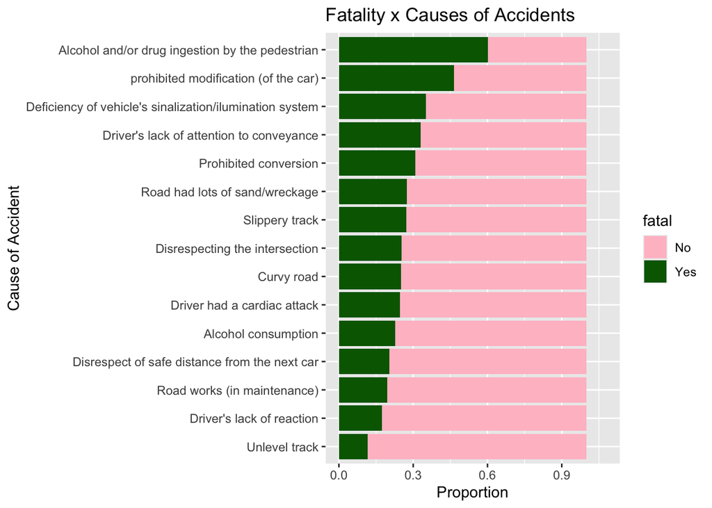

```r
plot_causes <- newaccidents2 %>%
  filter(cause_of_accident %in% top_causes) %>%
  group_by(cause_of_accident, fatal) %>%
  summarise(n = n(), .groups = "drop") %>%
  group_by(cause_of_accident) %>%
  mutate(prop = n/sum(n))


ggplot(plot_causes, aes(x = fct_reorder(cause_of_accident, ifelse(fatal == "Yes", prop, 0), .fun = max),
                        y = prop, fill = fatal)) +
  geom_col() +
  scale_fill_manual(values = c("No" = "pink", "Yes" = "darkgreen")) +
  coord_flip() +
  scale_x_discrete() +
  scale_y_continuous(limits = c(0, 1.08)) +
  labs(
    title = "Fatality x Causes of Accidents",
    x = "Cause of Accident",
    y = "Proportion"
  )
```

It appears that the most fatal type of car accident is when a pedestrian has ingested alcohol or drugs (60.1%), followed by prohibited modification of cars (46.6%), then deficiency of the vehicle’s sinalization/illumination system (~35.1%). On the opposite end of the plot at the bottom, the causes of accidents where there is the least fatality include maintenance work on the road (19.5%), drivers lack of reaction (17.5%), and unlevel track (11.7%).

There are obviously some causes of accidents that are more fatal than others, but the sample sizes appear small for some and can influence the perception of the fatality of an accident being more relevant in reality than it is. If the only recorded accidents involving modification of the car were fatal and there were only a small number of them, the proportion will be high.

### Vehicles Involved

```r
newaccidents2 %>%
  group_by(vehicles_involved) %>%
  summarize(fatal_rate = mean(fatal == "Yes")) %>%
  arrange(desc(fatal_rate))
```

```
## # A tibble: 17 × 2
##    vehicles_involved fatal_rate
##                <dbl>      <dbl>
##  1                14      1
##  2                21      1
##  3                23      1
##  4                 9      0.55
##  5                11      0.444
##  6                12      0.444
##  7                10      0.429
##  8                 8      0.425
##  9                 2      0.309
## 10                 3      0.303
## 11                 5      0.280
## 12                 4      0.263
## 13                 7      0.252
## 14                 1      0.248
## 15                 6      0.228
## 16                13      0
## 17                15      0
```

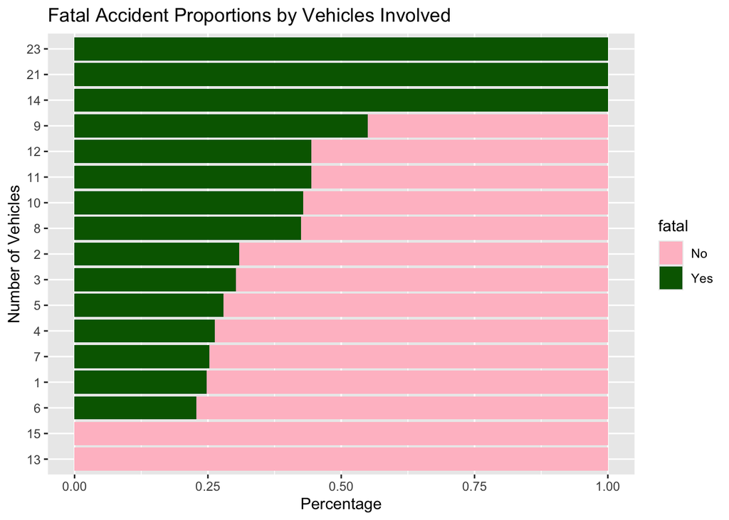

```r
vehicles_asc <- newaccidents2 %>%
  group_by(vehicles_involved) %>%
  summarize(fatal_rate = mean(fatal == "Yes")) %>%
  arrange(fatal_rate) %>%
  pull(vehicles_involved)

ggplot(newaccidents2, aes(x = factor(vehicles_involved, levels = vehicles_asc), fill = fatal)) +
  geom_bar(position = "fill") +
  scale_fill_manual(values = c("No" = "pink", "Yes" = "darkgreen")) +
  coord_flip() +
  labs(
    title = "Fatal Accident Proportions by Vehicles Involved",
    x = "Number of Vehicles",
    y = "Percentage"
  )
```

The plot is indicating that the most fatal accidents are the ones that involve more vehicles, and this makes sense logically. If there are more people, there are more points of impact and emergency response for a person can be delayed by the sheer number of people. On the other hand, the 100% fatality rate can be attributed to the low number of accidents that occur where there is that many people. Most car accidents occur between 1 and 2 cars and make up most of the fatalities. If you see in the tibble below:

```r
newaccidents2 %>%
  filter(vehicles_involved >= 10) %>%
  count(vehicles_involved)
```

```
## # A tibble: 8 × 2
##   vehicles_involved     n
##               <dbl> <int>
## 1                10    14
## 2                11     9
## 3                12     9
## 4                13     1
## 5                14     1
## 6                15     1
## 7                21     1
## 8                23     1
```

### Road Delineation

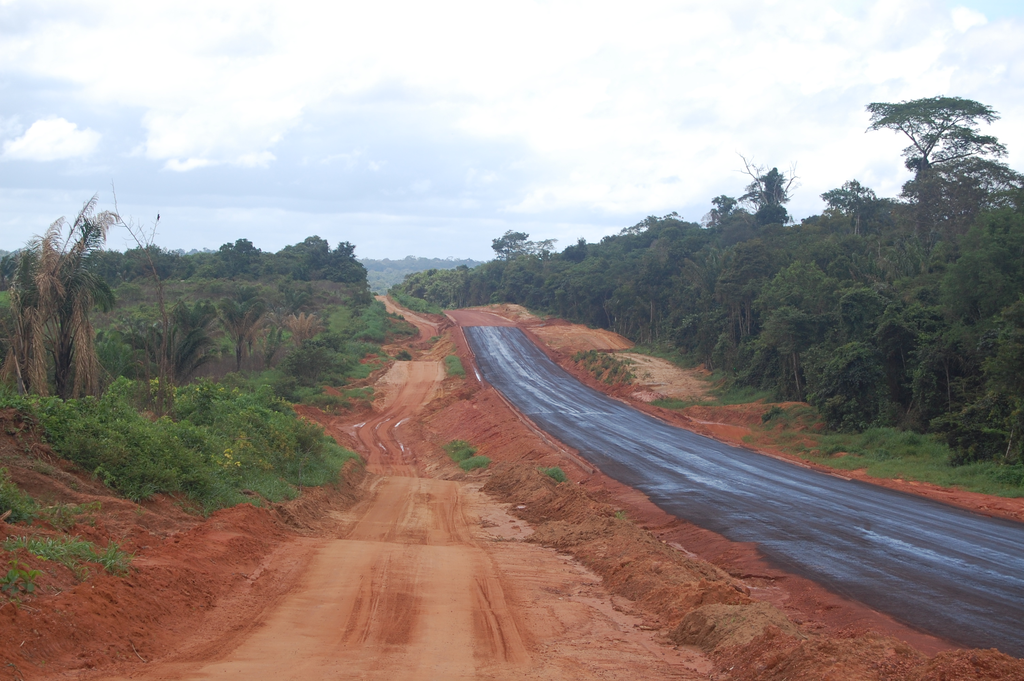

*Fig 3. Brazilian Dirt Path*

```r
newaccidents2 %>%
  group_by(road_delineation) %>%
  summarize(fatal_rate = mean(fatal == "Yes")) %>%
  arrange(desc(fatal_rate))
```

```
## # A tibble: 10 × 2
##    road_delineation  fatal_rate
##    <fct>                  <dbl>
##  1 Curve                  0.311
##  2 Intersection           0.298
##  3 Bridge                 0.297
##  4 Roundabout             0.283
##  5 Temporary Detour       0.271
##  6 Tunnel                 0.257
##  7 Not Reported           0.255
##  8 Straight               0.232
##  9 Authorized U-turn      0.227
## 10 Overpass               0.184
```

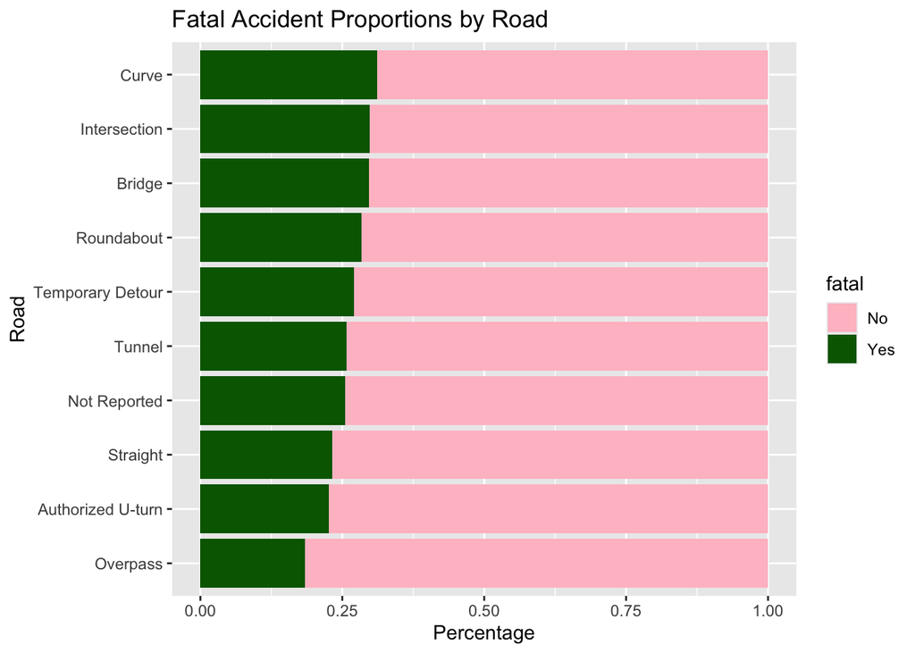

```r
road_asc <- newaccidents2 %>%
  group_by(road_delineation) %>%
  summarize(fatal_rate = mean(fatal == "Yes")) %>%
  arrange(fatal_rate) %>%
  pull(road_delineation)

newaccidents2$road_delineation <- factor(newaccidents2$road_delineation, levels = road_asc)

ggplot(newaccidents2, aes(x = road_delineation, fill = fatal)) +
  geom_bar(position = "fill") +
  scale_fill_manual(values = c("No" = "pink", "Yes" = "darkgreen")) +
  coord_flip() +
  labs(
    title = "Fatal Accident Proportions by Road",
    x = "Road",
    y = "Percentage"
  )
```

Road delineation was selected as a predictor on the assumption that roads that are more complex or uncommon may pose as more difficult for drivers to safely navigate and thus cause more accidents. This assumption is both true and untrue where it has actually been studied by the Traffic Safety Research[^6] in 2022, at least in the context of curves, sharp curves increase accident rate and areas with roads with many sharp curves do not have a higher accident rate than areas with less demanding alignment. This confusing truth is also present in the fatality proportion rate where curves are listed as most fatal, but its fatality rate is 31.14%, not an overwhelming proportion compared to the remaining 68.86% being non-fatal.

### Month

```r
newaccidents2 %>%
  group_by(month) %>%
  summarize(fatal_rate = mean(fatal == "Yes")) %>%
  arrange(desc(fatal_rate))
```

```
## # A tibble: 12 × 2
##    month fatal_rate
##    <dbl>      <dbl>
##  1     9      0.288
##  2     5      0.286
##  3    11      0.286
##  4    10      0.285
##  5     8      0.283
##  6     4      0.280
##  7    12      0.280
##  8     7      0.280
##  9     6      0.280
## 10     1      0.276
## 11     3      0.274
## 12     2      0.270
```

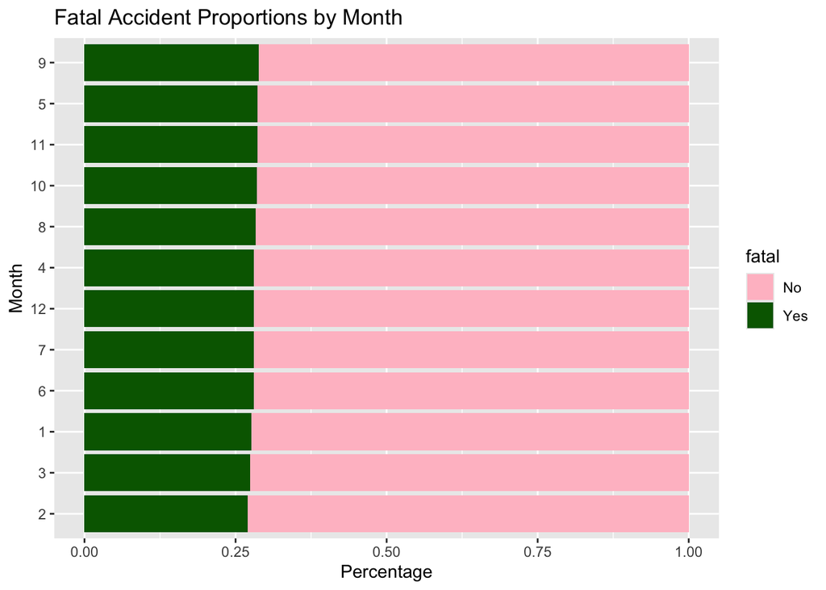

```r
month_asc <- newaccidents2 %>%
  group_by(month) %>%
  summarize(fatal_rate = mean(fatal == "Yes")) %>%
  arrange(fatal_rate) %>%
  pull(month)

ggplot(newaccidents2, aes(x = factor(month, levels = month_asc), fill = fatal)) +
  geom_bar(position = "fill") +
  scale_fill_manual(values = c("No" = "pink", "Yes" = "darkgreen")) +
  coord_flip() +
  labs(
    title = "Fatal Accident Proportions by Month",
    x = "Month",
    y = "Percentage"
  )
```

According to the National Safety Council (NSC)[^7], “the variation in monthly motor-vehicle fatalities is associate with the number of vehicle miles. During the winter months, vehicle miles and deaths go down, while vehicle miles and deaths increase in the summer months.” This pairs with the assumption that where there are more vehicles and activity on the road, accidents will increase.

There seems to be a similar proportion of accidents each month, with the highest proportion of fatal accidents occurring in September at 28.79% and the lowest proportion during February at 26.97%. The difference between those two is just 1.82%. So month may not be the most reliable predictor when it comes to describing and predicting how fatal an accident may be in this case.

### Year

```r
newaccidents2 %>%
  group_by(year) %>%
  summarize(fatal_rate = mean(fatal == "Yes")) %>%
  arrange(desc(fatal_rate))
```

```
## # A tibble: 4 × 2
##    year fatal_rate
##   <dbl>      <dbl>
## 1  2022      0.285
## 2  2023      0.283
## 3  2021      0.280
## 4  2020      0.274
```

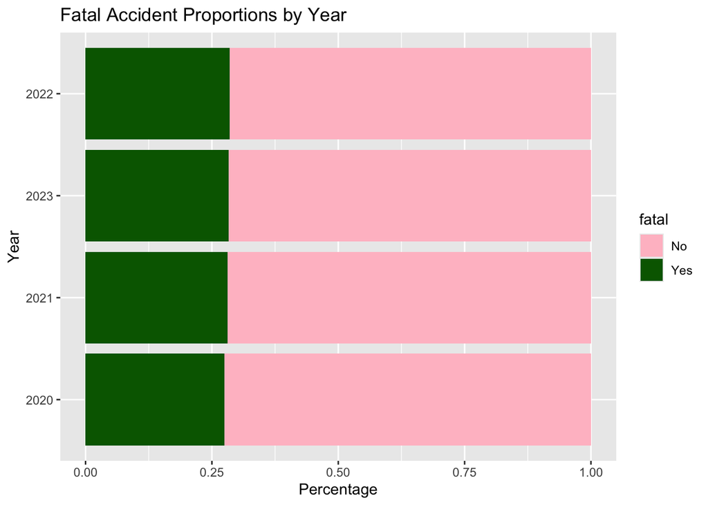

```r
year_asc <- newaccidents2 %>%
  group_by(year) %>%
  summarize(fatal_rate = mean(fatal == "Yes")) %>%
  arrange(fatal_rate) %>%
  pull(year)

ggplot(newaccidents2, aes(x = factor(year, levels = year_asc), fill = fatal)) +
  geom_bar(position = "fill") +
  scale_fill_manual(values = c("No" = "pink", "Yes" = "darkgreen")) +
  coord_flip() +
  labs(
    title = "Fatal Accident Proportions by Year",
    x = "Year",
    y = "Percentage"
  )
```

Year may not have the strongest prediction power, as the proportions are all similar and very close to each other. It is not the most informative predictor of fatal accidents as the difference between the highest proportion in 2022 (28.47%) and the lowest proportion in 2020 (27.44%) is 1.03%. I would speculate that fatal accidents are becoming more common and occurring more often than in previous years.

## Data Split into Training and Testing

Now that we’ve looked at the different predictors that may influence the prediction of a fatal accident, I want to begin running the data through different models that will tell us more concretely how fatal an accident is.

I should split my data in order to do so and it should be split and stratified based on the outcome variable, which is “fatal.” This split and stratification will occur for both the training and testing data sets. I will also need to set my seed to keep my results consistent.

```r
set.seed(18294)

fatal_split <- initial_split(newaccidents2, prop = 0.7, strata = fatal)
fatal_train <- training(fatal_split)
fatal_test <- testing(fatal_split)

length(newaccidents2$fatal)
```

```
## [1] 236697
```

```r
nrow(fatal_train)/nrow(newaccidents2)
```

```
## [1] 0.6999962
```

```r
nrow(fatal_test)/nrow(newaccidents2)
```

```
## [1] 0.3000038
```

The initial split successfully split itself into a proportion of 70% and 30% with the training and testing data respectively.

## K-fold Cross Validation

I will also use *k*-fold cross-validation on the training set to eventually fit the models to and use 5 folds. I use *k*-fold cross-validation to train my model on performing on new unseen data. My training data will be randomly split into 5 equal folds where a portion of the folds are used to train the model and a separate unused fold is used to evaluate the model. This will be repeated until every fold has been used to evaluate the model; the results of the evaluations will be averaged to receive a final estimate.

```r
f_folds <- vfold_cv(fatal_train, v=5, strata = fatal)
```

## Making my Recipe

Now I will make a recipe to use in the building of my models. Recipes essentially outline all the transformations I want the predictors to undergo before being run through a model and ensure the data is in the correct format that is necessary for the model to process.

```r
fatal_recipe <- recipe(fatal ~ state + cause_of_accident + type_of_accident + weather_timestamp + weather_condition + road_delineation + vehicles_involved + month + year, data = fatal_train) %>%
  step_novel(all_nominal_predictors()) %>%  # adds a category called "new" for any category that appears in the test but is not in the training set.
  step_other(all_nominal_predictors(), threshold = 0.01) %>% # any category that appears in less than 1% of your training data gets put into an "other" category
  step_dummy(all_nominal_predictors()) %>% # converts categorical variables into columns that contain a binary 0 or 1
  step_zv(all_predictors()) %>% # some dummy variables can contain no info and this step removes these columns
  step_center(all_predictors()) %>%
  step_scale(all_predictors())

prepped_fatal <- prep(fatal_recipe)
juiced_fatal <- juice(prepped_fatal)
ncol(juiced_fatal)
```

```
## [1] 76
```

Now that I’ve made the recipe, I can begin creating models, workflows, and grids if needed.

The models will learn and detect patterns in my training data to make decisions or predictions on new unseen testing data. The model should be inclusive of the parameters that exist internally in the data and hyper-parameters, like learning rate or batch size, where necessary. Models that I’ve interacted with before can prioritize optimization, adjusting parameters to minimize loss and improve model accuracy. The models I will be creating now are supervised classification models, models that learn from labeled data and assign input data into predefined categories.

## Models and Workflows

To fit my models, I am selecting five different ones to fit to the data: logistic regression, linear discriminant, elastic net, quadratic discriminant, and k-nearest neighbors. To do so, I will first set up workflows for all five of them.

### Logistic Regression model

```r
fatal_log <- logistic_reg() %>%
  set_engine("glm") %>%
  set_mode("classification")

log_wf <- workflow() %>%
  add_recipe(fatal_recipe) %>%
  add_model(fatal_log)
```

### Linear Discriminant Model

```r
lda_model <-  discrim_linear() %>%
  set_engine("MASS") %>%
  set_mode("classification")

lda_wf <- workflow() %>%
  add_recipe(fatal_recipe) %>%
  add_model(lda_model)
```

### Elastic Net

```r
enet_model <- logistic_reg(
  penalty = tune(),
  mixture = tune()
) %>%
  set_engine("glmnet") %>%
  set_mode("classification")

enet_wf <- workflow() %>%
  add_recipe(fatal_recipe) %>%
  add_model(enet_model)

enet_grid <- grid_regular(
  penalty(range = c(log10(0.01), log10(3))),
  mixture(range = c(0,1)),
  levels = 10
)
```

### Quadratic Discriminant Analysis

```r
quad_model <- discrim_quad() %>%
  set_engine("MASS") %>%
  set_mode("classification")

quad_wf <- workflow() %>%
  add_recipe(fatal_recipe) %>%
  add_model(quad_model)
```

### K-Nearest Neighbors

```r
knn_model <-  nearest_neighbor(neighbors = 5) %>%
  set_engine("kknn") %>%
  set_mode("classification")

knn_wf <- workflow() %>%
  add_recipe(fatal_recipe) %>%
  add_model(knn_model)
```

## Fitting my models

To fit the models, I will be running them and saving the results in a separate file and loading them in this one to minimize the knitting time. My data set with over 200,000 observations easily causes my models to have a long run time, especially with the step of *k*-fold cross validation creating five folds. I originally wanted to include a random forest model, but the amount of trees also multiplied the run time. With my attempts at a random forest model, it showed no sign of completion as I let it run over 24 hours. I already reduced my data set by half, and in order to prioritize the reliability of results and accurate reflection of the patterns that occur in the data, I did not want to reduce my data any more just to accelerate the run time.

```r
dir.create("results2", showWarnings = FALSE)

fitted_log <- fit_resamples(
  log_wf,
  resamples = f_folds,
  metrics = metric_set(roc_auc, accuracy),
  control = control_resamples(save_pred = TRUE)
)

fitted_quad <- fit_resamples(
  quad_wf,
  resamples = f_folds,
  metrics = metric_set(roc_auc, accuracy),
  control = control_resamples(save_pred = TRUE)
)

fitted_lda <- fit_resamples(
  lda_wf,
  resamples = f_folds,
  metrics = metric_set(roc_auc, accuracy),
  control = control_resamples(save_pred = TRUE)
)

fitted_enet <- tune_grid(
  enet_wf,
  resamples = f_folds,
  grid = enet_grid,
  metrics = metric_set(roc_auc, accuracy),
  control = control_grid(save_pred = TRUE)
)

fitted_knn <- fit_resamples(
  knn_wf,
  resamples = f_folds,
  metrics = metric_set(roc_auc, accuracy),
  control = control_resamples(save_pred = TRUE)
)

save(fitted_log, file = "results2/log_results.rda")
save(fitted_quad, file = "results2/quad_results.rda")
save(fitted_lda, file = "results2/lda_results.rda")
save(fitted_enet, file = "results2/enet_results.rda")
save(fitted_knn, file = "results2/knn_results.rda")
```

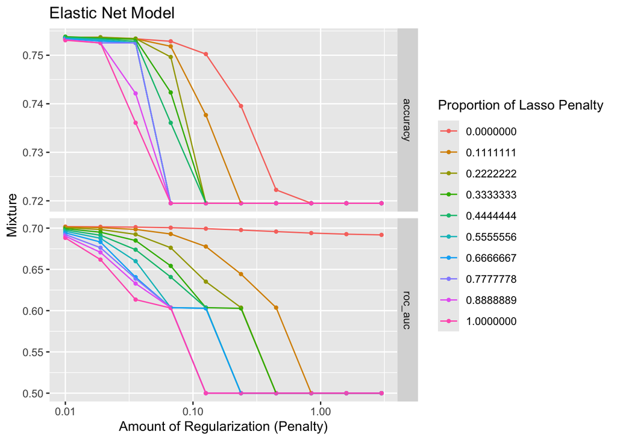

```r
load("results2/log_results.rda")
load("results2/quad_results.rda")
load("results2/lda_results.rda")
load("results2/enet_results.rda")
load("results2/knn_results.rda")

log_metrics <- collect_metrics(fitted_log) %>% mutate(model = "Logistic")
quad_metrics <- collect_metrics(fitted_quad) %>% mutate(model = "Quadratic")
lda_metrics <- collect_metrics(fitted_lda) %>% mutate(model = "LDA")
knn_metrics <- collect_metrics(fitted_knn) %>% mutate(model = "KNN")
enet_metrics <- collect_metrics(fitted_enet) %>% mutate(model = "Elastic Net")

autoplot(fitted_enet) +
  labs(
    title = "Elastic Net Model",
    x = "Amount of Regularization (Penalty)",
    y = "Mixture"
  )
```

```r
bind_rows(log_metrics, quad_metrics, lda_metrics, knn_metrics, enet_metrics) %>%
  filter(.metric == "roc_auc") %>%
  select(model, mean, std_err) %>%
  arrange(desc(mean))
```

```
## # A tibble: 104 × 3
##    model        mean std_err
##    <chr>       <dbl>   <dbl>
##  1 Logistic    0.702 0.00123
##  2 LDA         0.702 0.00130
##  3 Elastic Net 0.702 0.00130
##  4 Elastic Net 0.702 0.00135
##  5 Elastic Net 0.701 0.00137
##  6 Elastic Net 0.701 0.00142
##  7 Elastic Net 0.701 0.00147
##  8 Elastic Net 0.701 0.00146
##  9 Elastic Net 0.701 0.00152
## 10 Elastic Net 0.699 0.00153
## # ℹ 94 more rows
```

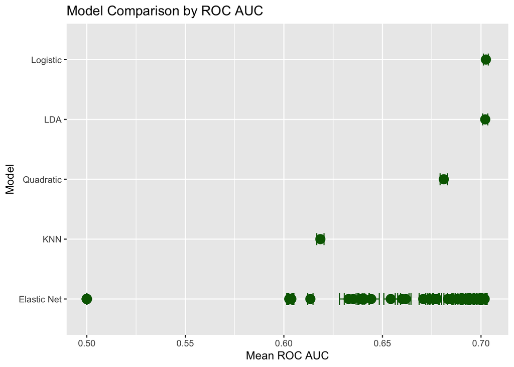

```r
bind_rows(log_metrics, quad_metrics, lda_metrics, knn_metrics, enet_metrics) %>%
  filter(.metric == "roc_auc") %>%
  select(model, mean, std_err) %>%
  ggplot(aes(x = reorder(model, mean), y = mean)) +
  geom_point(size = 4, color = "darkgreen") +
  geom_errorbar(aes(ymin = mean - std_err, ymax = mean + std_err),
                width = 0.2, color = "darkgreen") +
  coord_flip() +
  labs(title = "Model Comparison by ROC AUC",
       x = "Model", y = "Mean ROC AUC")
```

In the model comparison plot and tibble, it indicates the logistic regression model and linear discriminant model reaching 70.25% and 70.21% mean ROC AUC and the elastic net model not far behind at 70.19%. Quadratic rings in next at 68.11% and then KNN at 61.85%. I do not think this is a significantly large range that would lead me to say that one model performed drastically worse in comparison to the best one.

The model with the highest ROC AUC will be the one that has the best performance and ability to differentiate if an accident is fatal or not, and in this case, it is the logistic regression and linear discriminant analysis model.

Another way to visualize the ROC AUC means is to make an ROC AUC curve plot.

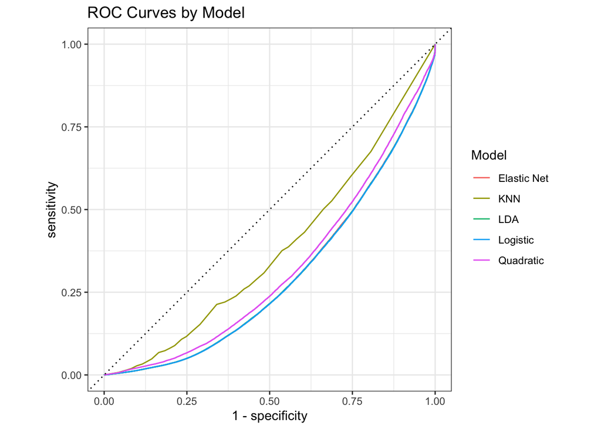

```r
load("results2/log_results.rda")
load("results2/quad_results.rda")
load("results2/lda_results.rda")
load("results2/enet_results.rda")
load("results2/knn_results.rda")

log_preds  <- collect_predictions(fitted_log)  %>% mutate(model = "Logistic")
quad_preds <- collect_predictions(fitted_quad) %>% mutate(model = "Quadratic")
lda_preds  <- collect_predictions(fitted_lda)  %>% mutate(model = "LDA")
knn_preds  <- collect_predictions(fitted_knn)  %>% mutate(model = "KNN")
enet_preds <- collect_predictions(fitted_enet, parameters = select_best(fitted_enet, metric = "roc_auc")) %>%
  mutate(model = "Elastic Net")

# bind and plot all ROC curves together
bind_rows(log_preds, quad_preds, lda_preds, knn_preds, enet_preds) %>%
  group_by(model) %>%
  roc_curve(truth = fatal, .pred_Yes) %>%
  autoplot() +
  labs(
    title = "ROC Curves by Model",
    color = "Model"
  )
```

Now having been able to determine the best performing model, I can fit the testing data to it and evaluate its performance and actual capabilities of predicting fatal car accidents in Brazil.

## Testing my Model

### How I feel about the ROC AUC

The ROC AUC scores of 70.25% and 70.21% are on the moderate size; ideally, it should be as close to 100% as possible but around 70% is not upsetting. It’s preferable than the odds of 50/50 random guessing! Still, it indicates that these are imperfect models and have the potential to be better. There is a possibility that the predictors I provided were not sufficient, and I potentially excluded some predictors that might have been useful. For logistic regression, it definitely could have benefited more if there were more informative predictors. And also because the model is a linear model, if the relationship between predictors and fatality includes complex interactions, logistic regression is not predisposed to capture that information.

Despite all of this, I have decent faith in my models to also get a decent outcome when I fit it to the testing data. With similar ROC AUC scores from both logistic regression and linear discriminant, I am led to believe that these outcomes are not flukes or strokes of luck.

### Fitting to my Testing Data

Now, I shall fit the logistic regression model on my testing data. We will be able to evaluate how the model performs on data it has never seen before.

```r
# fitting chosen model to entire training set
log_fitted_train <- fit(log_wf, data = fatal_train)
```

```r
# using augment() to assess the performance of logistic regression on testing set
log_fitted_test <- augment(log_fitted_train, new_data = fatal_test)

# test set ROC AUC
test_rocauc <-log_fitted_test %>%
  roc_auc(truth = fatal, .pred_No)

# test set accuracy
test_accuracy <- log_fitted_test %>%
  accuracy(truth = fatal, .pred_class)

# test set testing error
test_error <- test_accuracy %>%
  mutate(testing_error = 1 - .estimate) %>%
  select(testing_error)

# cross validation ROC AUC
testavgrocauc <- log_metrics %>%
  filter(.metric == "roc_auc") %>%
  select(mean, std_err)

# comparing the test set ROC AUC and the cross validation ROC AUC
test_rocauc
```

```
## # A tibble: 1 × 3
##   .metric .estimator .estimate
##   <chr>   <chr>          <dbl>
## 1 roc_auc binary         0.703
```

```r
test_accuracy
```

```
## # A tibble: 1 × 3
##   .metric  .estimator .estimate
##   <chr>    <chr>          <dbl>
## 1 accuracy binary         0.754
```

```r
test_error
```

```
## # A tibble: 1 × 1
##   testing_error
##           <dbl>
## 1         0.246
```

```r
testavgrocauc
```

```
## # A tibble: 1 × 2
##    mean std_err
##   <dbl>   <dbl>
## 1 0.702 0.00123
```

- The reported ROC AUC score from the testing set after being fit to the logistic regression model is 70.31%.
- The reported accuracy of the testing set after being fit to the logistic regression model is 75.36%.
- The testing error of the testing set after being fit to the logistic regression model is 24.64%.
- The reported ROC AUC score from the cross validation is 70.25%.

The difference between the ROC AUC score from the testing set and the ROC AUC score from cross validation is only 0.06%, is insignificant and indicates a near-perfect consistency between my cross validation estimate and my actual test data performance.

The testing error of 24.64% indicates that 1 in 4 accidents were incorrectly categorized by my model.

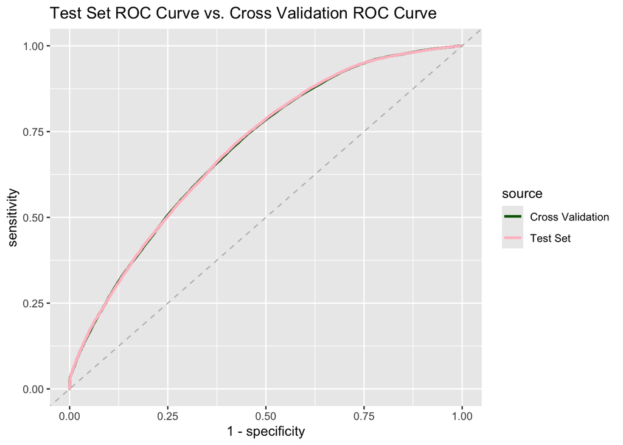

```r
cv_curve <- collect_predictions(fitted_log) %>%
  roc_curve(truth = fatal, .pred_No) %>%
  mutate(source = "Cross Validation")

test_curve <- log_fitted_test %>%
  roc_curve(truth = fatal, .pred_No) %>%
  mutate(source = "Test Set")

# visualization of both ROC AUC
bind_rows(test_curve, cv_curve) %>%
  ggplot(aes(x = 1 - specificity, y = sensitivity, color = source)) +
  geom_line(linewidth = 1) +
  geom_abline(lty = 2, color = "gray") +
  scale_color_manual(values = c("Test Set" = "pink",
                                "Cross Validation" = "darkgreen")) +
  labs(
    title = "Test Set ROC Curve vs. Cross Validation ROC Curve"
  )
```

The y-axis labeled “sensitivity” measures how many fatal accidents did the model correctly catch, and the x-axis labeled “1-specificity” measures how many non-fatal accidents did the model incorrectly flag as fatal. Signs of a good model would veer to the top left corner more than any other.

Looking at the ROC curves, they’re almost identical! I can barely see the cross validation curve under the test set curve. The fact that both of them are above the reference diagonal line indicates that the model is performing well and has generalized to the new unseen testing data. The apex of the curve does seem to be closest to the top left corner of the plot. I see no signs of overfitting and the consistency it displays for the lines to be directly on top of each other leads me to believe that the processes of fitting the model to the training data and then the testing data were accurate.

# Conclusion

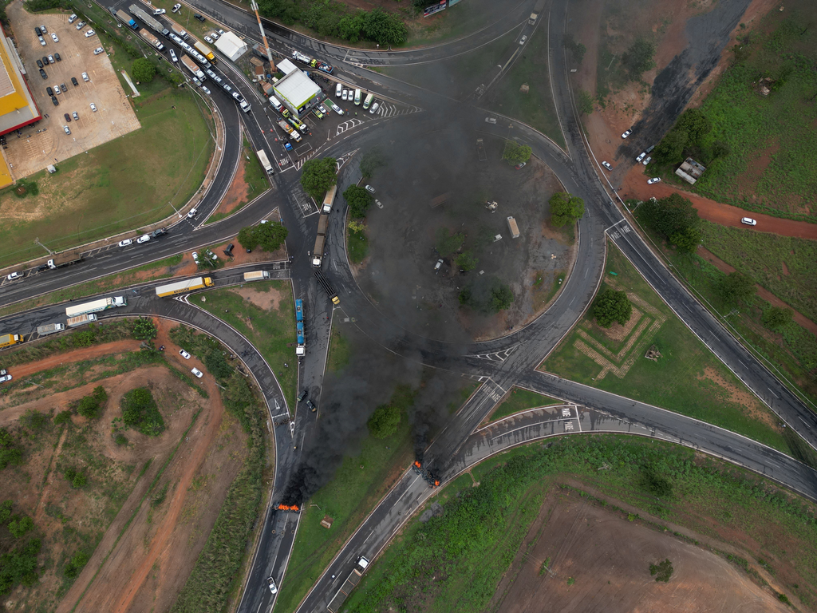

*Fig 4. Truck Blockade*

At the beginning of this project, I set out to predict whether a car accident in Brazil would be fatal using a dataset that I reduced into 236,697 observations, spanning from 2020 to 2023. After studying the data set, I set out to use nine variables as predictors for my recipe that would precede the use of any models. Those predictors include: state, weather conditions, weather timestamp, type of car accident, the cause of the car accident, the number of vehicles involved, road delineation, month, and year. These predictors would all serve me in the building of five classification models that I divided into five folds for *k*-fold cross validation. The models that I eventually decided on were logistic regression, linear discriminant analysis, elastic net, quadratic discriminant analysis, and K-nearest neighbors.

The data was separated into two portions, a training set and a testing set. After fitting the models to the training set, the logistic regression and linear discriminant analysis model had the best performance in terms of mean ROC AUC at 70.25% and 70.21% respectively. The other models also performed fairly well, the KNN model, the lowest one, being only within a 9% difference from the best one. The top three models, logistic regression, linear discriminant analysis, and elastic net are nearly identical to each other in terms of ROC AUC.

Despite this confidence and the moderate score of 70.25%, there are still improvements that can be made to the model to maximize its abilities in actually being able to predict fatal car accidents in Brazil. Perhaps there were better models to fit to this data that would have improved the ROC AUC mean score, like random forest models or boosted gradient models, or there may have been an insufficient presence of meaningful predictors. The predictor `cause_of_accident` had 85 unique values, some too rare for it to be meaningful to the model and I reduced the 85 into the most common 15 causes. Maybe if the causes were better categorized into simple and precise categories, the models would have received it better. Additionally, logistic regression is a linear model, it is unable to fully encapsulate any complex interactions between predictors that may contribute towards being able to predict which accidents are going to be fatal. Moreover, there was a dramatic class imbalance between fatal accidents and non-fatal accidents which would have contributed to any inability to detect the minority class and distinguish if an accident was fatal or not. Future research can take these improvements into consideration if there is such another one that endeavors to predict the fatality of a car accident that occurs in Brazil. I would love to see a model that reduces my testing error from 25% to near zero.

[^1]: National Library of Medicine, *Road traffic injuries and deaths and the achievement of UN Sustainable Development Goals in Brazil: results from the Global Burden of Disease Study, 1990 to 2019*, United States, 2022, https://pmc.ncbi.nlm.nih.gov/articles/PMC9038143/
[^2]: Insurance Institute for Highway Safety, *Fatality Facts 2023*, United States, 2025, https://www.iihs.org/research-areas/fatality-statistics/detail/state-by-state
[^3]: Kaggle, *Car Accidents in Brazil (2017-2023)*, United States, 2025, https://www.kaggle.com/datasets/mlippo/car-accidents-in-brazil-2017-2023
[^4]: National Highway Traffic Safety Administration, *ANSI D16.1-1996: Manual on Classification of Motor Vehicle Traffic Accidents*, New Jersey, 1996, https://www-fars.nhtsa.dot.gov/help/terms.aspx
[^5]: Department of Transportation’s Federal Highway Administration, *How Do Weather Events Affect Roads?*, United States, 2025, https://ops.fhwa.dot.gov/weather/roadimpact.htm
[^6]: Traffic Safety Research, *Which is the more important for road safety—road design or driver behavioural adaptation?*, Norway, 2022, https://tsr.international/TSR/article/view/24032
[^7]: National Safety Council, *Crashes by Month*, United States, 2023, https://injuryfacts.nsc.org/motor-vehicle/overview/crashes-by-month/